# Optimización

```
Author: Jesús Cid-Sueiro
        Jerónimo Arenas-García

Versión: 0.1 (2019/09/13)
         0.2 (2019/10/02): Solutions added
```

## Exercise: compute the minimum of a real-valued function

The goal of this exercise is to implement and test optimization algorithms for the minimization of a given function. Gradient descent and Newton's method will be explored.

Our goal it so find the minimizer of the real-valued function $$ f(w) = - w exp(-w) $$ but the whole code will be easily modified to try with other alternative functions.

You will need to import some libraries (at least, `numpy` and `matplotlib`). Insert below all the imports needed along the whole notebook. Remind that numpy is usually abbreviated as np and `matplotlib.pyplot` is usually abbreviated as `plt`.

```python
# <SOL>
import numpy as np
import matplotlib.pyplot as plt
# </SOL>
```

### Part 1: The function and its derivatives.

**Question 1.1**: Implement the following three methods:

- Method **`f`**: given $w$, it returns the value of function $f(w)$.
- Method **`df`**: given $w$, it returns the derivative of $f$ at $w$
- Medhod **`d2f`**: given $w$, it returns the second derivative of $f$ at $w$

```python
# Funcion f
# <SOL>
def f(w):
    y = - w * np.exp(-w)
    return y
# </SOL>

# First derivative
# <SOL>
def df(w):
    y = (w -1) * np.exp(-w)
    return y
# </SOL>

# Second derivative
# <SOL>
def d2f(w):
    y = (2 - w) * np.exp(-w)
    return y
# </SOL>
```

### Part 2: Gradient descent.

**Question 2.1**: Implement a method **`gd`** that, given `w` and a learning rate parameter `rho` applies a single iteration of the gradien descent algorithm

```python
# <SOL>
def gd(w0, rho):
    y = w0 - rho * df(w)
    return y
# </SOL>
```

**Question 2.2**: Apply the gradient descent to optimize the given function. To do so, start with an initial value $w=0$ and iterate $20$ times. Save two lists:

- A list of succesive values of $w_n$
- A list of succesive values of the function $f(w_n)$.

```python
# <SOL>
wn = []
fwn = []
niter = 20
rho = 0.2
w = 0
wn.append(w)
fwn.append(f(w))

for k in range(niter):
    w = gd(w,rho)
    wn.append(w)
    fwn.append(f(w))
# </SOL>
```

**Question 2.3**: Plot, in a single figure:

- The given function, for values ranging from 0 to 20.
- The sequence of points $(w_n, f(w_n))$.

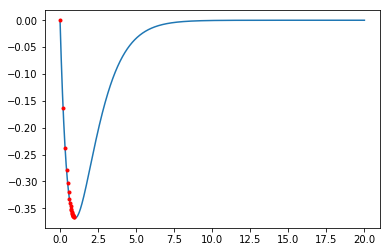

```python
# <SOL>
npoints = 1000
w_grid = np.linspace(0,20,npoints)
plt.plot(w_grid, f(w_grid))
plt.plot(wn,fwn,'r.')
plt.show()
# </SOL>
```

You can check the effect of modifying the value of the learning rate.

### Part 2: Newton's method.

**Question 3.1**: Implement a method **`newton`** that, given `w` and a learning rate parameter `rho` applies a single iteration of the Newton's method

```python
# <SOL>
def newton(w0, rho):
    y = w0 - rho * df(w) / d2f(w)
    return y
# </SOL>
```

**Question 3**: Apply the Newton's method to optimize the given function. To do so, start with an initial value $w=0$ and iterate $20$ times. Save two lists:

- A list of succesive values of $w_n$
- A list of succesive values of the function $f(w_n)$.

```python
# <SOL>
wn = []
fwn = []
niter = 20
rho = 0.5
w = 0
wn.append(w)
fwn.append(f(w))

for k in range(niter):
    w = newton(w,rho)
    wn.append(w)
    fwn.append(f(w))
# </SOL>
```

**Question 4**: Plot, in a single figure:

- The given function, for values ranging from 0 to 20.
- The sequence of points $(w_n, f(w_n))$.

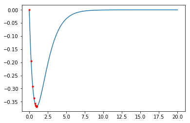

```python
# <SOL>
npoints = 1000
w_grid = np.linspace(0,20,npoints)
plt.plot(w_grid, f(w_grid))
plt.plot(wn,fwn,'r.')
plt.show()
# </SOL>
```

You can check the effect of modifying the value of the learning rate.

### Part 3: Optimize other cost functions

Now you are ready to explore these optimization algorithms with other more sophisticated functions. Try with them.